# ProjektCV

Milosz Alfler i Szymon Dufek

2023-06-30

# Projekt z przedmiotu automatyczna analiza obrazu

## Cel

Celem naszego projektu było zbudowanie jak najelepszej sieci splotowej do zadania klasyfikacyjnego na zadanym zbiorze zdjęć.

## Opis zbioru

W pracy użyliśmy gotowy zbiór danych ze stronny kaggle [(link)](https://www.kaggle.com/datasets/gpiosenka/butterfly-images40-species). Zbiór przedstawia 13594 zjęć motyli i ciem o wymiarze 224px na 224 px w kolorze.

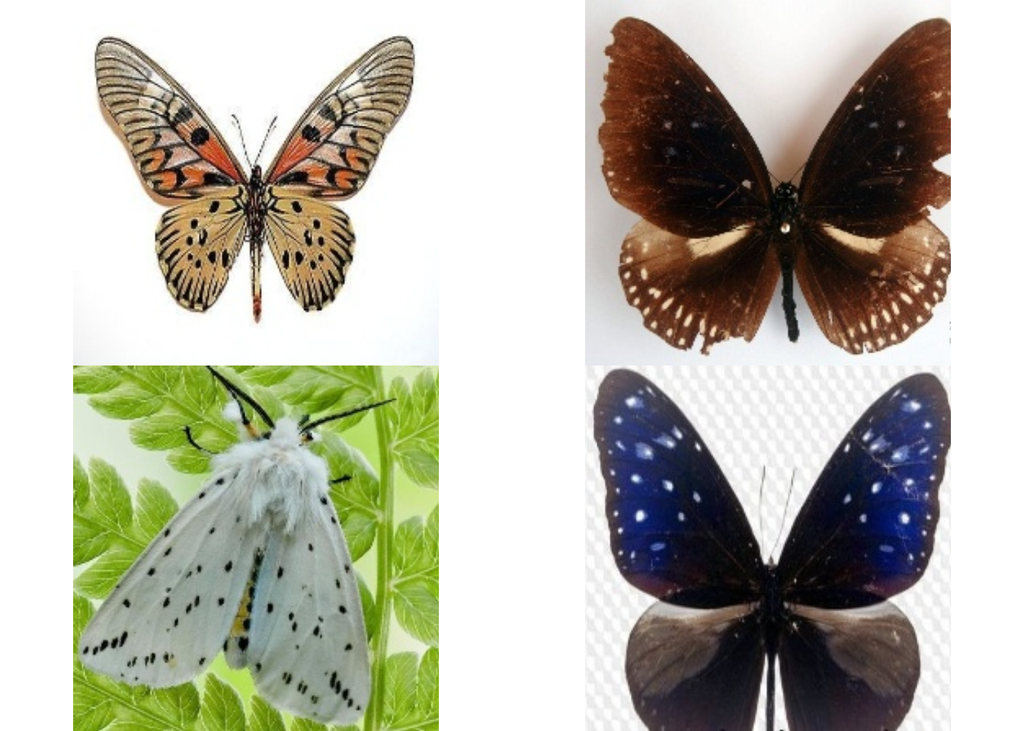

W zbiorze mamy 100 różnych gatunków

| Gatunki |
| --- |
| ADONIS |
| AFRICAN GIANT SWALLOWTAIL |
| AMERICAN SNOOT |
| AN 88 |
| APPOLLO |
| ARCIGERA FLOWER MOTH |
| ATALA |
| ATLAS MOTH |
| BANDED ORANGE HELICONIAN |
| BANDED PEACOCK |
| BANDED TIGER MOTH |
| BECKERS WHITE |
| BIRD CHERRY ERMINE MOTH |
| BLACK HAIRSTREAK |
| BLUE MORPHO |
| BLUE SPOTTED CROW |
| BROOKES BIRDWING |
| BROWN ARGUS |
| BROWN SIPROETA |
| CABBAGE WHITE |
| CAIRNS BIRDWING |
| CHALK HILL BLUE |
| CHECQUERED SKIPPER |
| CHESTNUT |
| CINNABAR MOTH |
| CLEARWING MOTH |
| CLEOPATRA |
| CLODIUS PARNASSIAN |
| CLOUDED SULPHUR |
| COMET MOTH |

[output cut: 70 more lines]

Dane zostały podzielone na zbiór uczący, validacyjny i testowy w proporcjach:

- Zbiór uczący zawiera 12594 zdjęcia w 100 katalogach oznaczających gatunki. Wielkości poszczególnych katalogów są różne, ale zawierają około 100 obrazków.
- Zbiór walidacyjny i testowy składają się z 500 zdjęć także podzielonych na 100 katalogów, a w każdym katalogu znajduje się po 5 obrazków dla danego gatunku.

## Proces uczenia

Jako funkcje straty dla wszystkich sieci użyliśmy “categorical_crossentropy”, a jako optimizer przyjeliśmy “rmsprop”. Grupy były zbalansowane więc za miarę do oceny posłużyła nam miara “accuracy”. Dodatkowo w ostatniej warstwie gęstej jako funkcje aktywacji przyjeliśmy funkcje “softmax”.

Prace zaczeliśmy od mało skomplikowanej sieci.

### Model 1

```
## Model: "sequential"
## ________________________________________________________________________________
##  Layer (type)                       Output Shape                    Param #
## ================================================================================
##  conv2d_5 (Conv2D)                  (None, 150, 150, 16)            448
##  conv2d_4 (Conv2D)                  (None, 150, 150, 32)            4640
##  conv2d_3 (Conv2D)                  (None, 148, 148, 64)            18496
##  max_pooling2d_2 (MaxPooling2D)     (None, 74, 74, 64)              0
##  conv2d_2 (Conv2D)                  (None, 74, 74, 16)              9232
##  conv2d_1 (Conv2D)                  (None, 72, 72, 32)              4640
##  max_pooling2d_1 (MaxPooling2D)     (None, 36, 36, 32)              0
##  conv2d (Conv2D)                    (None, 34, 34, 64)              18496
##  max_pooling2d (MaxPooling2D)       (None, 17, 17, 64)              0
##  flatten (Flatten)                  (None, 18496)                   0
##  dense_2 (Dense)                    (None, 256)                     4735232
##  dense_1 (Dense)                    (None, 64)                      16448
##  dense (Dense)                      (None, 100)                     6500
## ================================================================================
## Total params: 4,814,132
## Trainable params: 4,814,132
## Non-trainable params: 0
## ________________________________________________________________________________
```

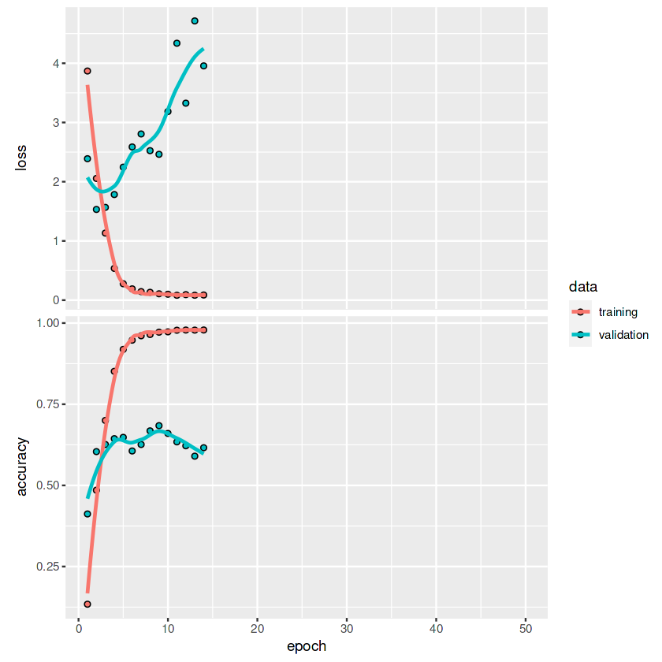

Wykresy accuracy i loss function na zbiorze uczącym

### Model 2

Ze względu na wyraźne przuczenie postanowiliśmy dodać opcje dropout.

```
## Model: "sequential_1"
## ________________________________________________________________________________
##  Layer (type)                       Output Shape                    Param #
## ================================================================================
##  conv2d_11 (Conv2D)                 (None, 150, 150, 16)            448
##  conv2d_10 (Conv2D)                 (None, 150, 150, 32)            4640
##  conv2d_9 (Conv2D)                  (None, 148, 148, 64)            18496
##  max_pooling2d_5 (MaxPooling2D)     (None, 74, 74, 64)              0
##  dropout_4 (Dropout)                (None, 74, 74, 64)              0
##  conv2d_8 (Conv2D)                  (None, 74, 74, 16)              9232
##  conv2d_7 (Conv2D)                  (None, 72, 72, 32)              4640
##  max_pooling2d_4 (MaxPooling2D)     (None, 36, 36, 32)              0
##  dropout_3 (Dropout)                (None, 36, 36, 32)              0
##  conv2d_6 (Conv2D)                  (None, 34, 34, 64)              18496
##  max_pooling2d_3 (MaxPooling2D)     (None, 17, 17, 64)              0
##  dropout_2 (Dropout)                (None, 17, 17, 64)              0
##  flatten_1 (Flatten)                (None, 18496)                   0
##  dense_5 (Dense)                    (None, 256)                     4735232
##  dropout_1 (Dropout)                (None, 256)                     0
##  dense_4 (Dense)                    (None, 64)                      16448
##  dropout (Dropout)                  (None, 64)                      0
##  dense_3 (Dense)                    (None, 100)                     6500
## ================================================================================
## Total params: 4,814,132
## Trainable params: 4,814,132
## Non-trainable params: 0
## ________________________________________________________________________________
```

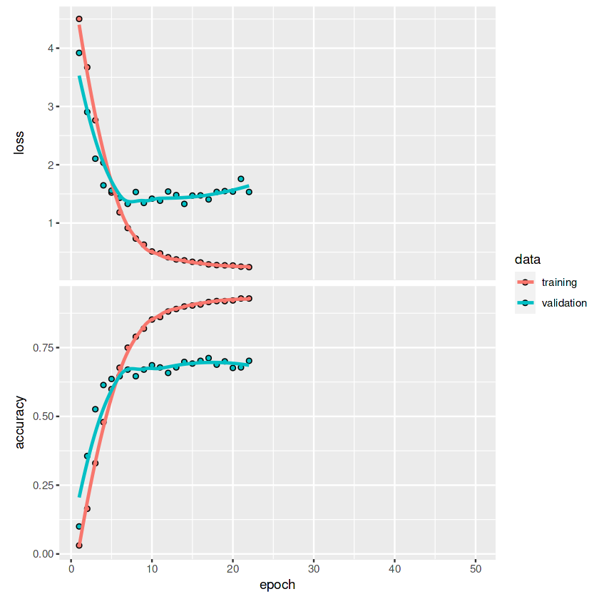

Wykresy accuracy i loss function na zbiorze uczącym

### Model 3

Jako iż model nadal wyglądał na przeuczony kolejnym etapem było zmiana funkcji aktywacji w warstwach na leaky_relu.

```
## Model: "sequential_2"
## ________________________________________________________________________________
##  Layer (type)                       Output Shape                    Param #
## ================================================================================
##  conv2d_17 (Conv2D)                 (None, 150, 150, 16)            448
##  leaky_re_lu_7 (LeakyReLU)          (None, 150, 150, 16)            0
##  conv2d_16 (Conv2D)                 (None, 150, 150, 32)            4640
##  leaky_re_lu_6 (LeakyReLU)          (None, 150, 150, 32)            0
##  conv2d_15 (Conv2D)                 (None, 148, 148, 64)            18496
##  leaky_re_lu_5 (LeakyReLU)          (None, 148, 148, 64)            0
##  max_pooling2d_8 (MaxPooling2D)     (None, 74, 74, 64)              0
##  dropout_9 (Dropout)                (None, 74, 74, 64)              0
##  conv2d_14 (Conv2D)                 (None, 74, 74, 16)              9232
##  leaky_re_lu_4 (LeakyReLU)          (None, 74, 74, 16)              0
##  conv2d_13 (Conv2D)                 (None, 72, 72, 32)              4640
##  leaky_re_lu_3 (LeakyReLU)          (None, 72, 72, 32)              0
##  max_pooling2d_7 (MaxPooling2D)     (None, 36, 36, 32)              0
##  dropout_8 (Dropout)                (None, 36, 36, 32)              0
##  conv2d_12 (Conv2D)                 (None, 34, 34, 64)              18496
##  leaky_re_lu_2 (LeakyReLU)          (None, 34, 34, 64)              0
##  max_pooling2d_6 (MaxPooling2D)     (None, 17, 17, 64)              0
##  dropout_7 (Dropout)                (None, 17, 17, 64)              0
##  flatten_2 (Flatten)                (None, 18496)                   0
##  dense_8 (Dense)                    (None, 256)                     4735232
##  leaky_re_lu_1 (LeakyReLU)          (None, 256)                     0
##  activity_regularization_1 (Activit  (None, 256)                    0
##  yRegularization)
##  dropout_6 (Dropout)                (None, 256)                     0
##  dense_7 (Dense)                    (None, 64)                      16448
##  leaky_re_lu (LeakyReLU)            (None, 64)                      0
##  activity_regularization (ActivityR  (None, 64)                     0
##  egularization)
##  dropout_5 (Dropout)                (None, 64)                      0
##  dense_6 (Dense)                    (None, 100)                     6500
## ================================================================================
## Total params: 4,814,132
## Trainable params: 4,814,132
## Non-trainable params: 0
## ________________________________________________________________________________
```

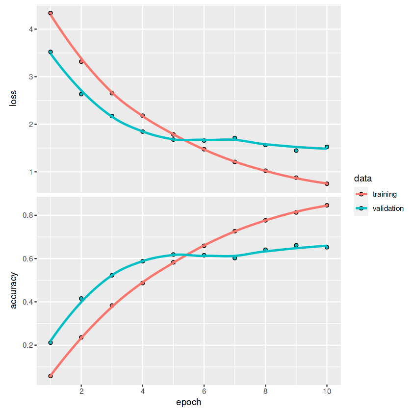

Wykresy accuracy i loss function na zbiorze uczącym

### Model 4

Pomimo opcji dropout i leaky_relu model nadal wyglądał na przeuczony więc w następnym modelu sprawdziliśmy jak nasza sięc poradzi sobie z dodaniem opcji augmentacji.

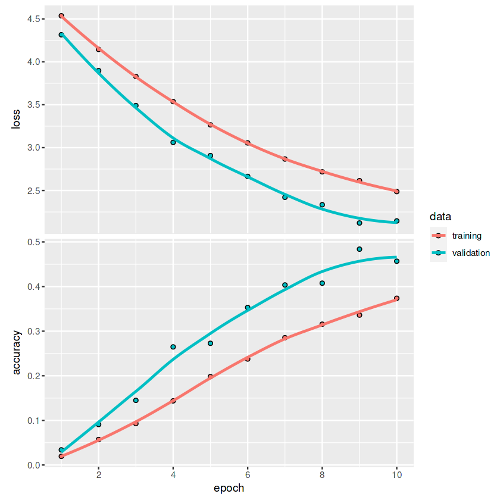

Wykresy accuracy i loss function na zbiorze uczącym

```r
train_datagen <- image_data_generator(rescale = 1/255,
                                     validation_split=0.2,
                                      rotation_range = 40,
  width_shift_range = 0.2,
  height_shift_range = 0.2,
  shear_range = 0.2,
  zoom_range = 0.2,
  horizontal_flip = TRUE,
  fill_mode = "nearest"
                                       )
```

Augmentacja pomogła pozbyć się przeuczenia modelu więc ją zostawiliśmy na kolejne etapy.

### Model 5

Następnie jako iż siec nie wyglądała na przeuczoną pozbyliśmy się dropoutów.

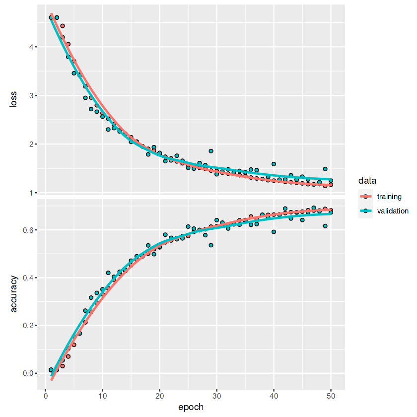

Wykresy accuracy i loss function na zbiorze uczącym

### Model 6

Kolejnym etapem było przetestowanie jak zmiana szybkości uczenia wpłynie na naszą sieć. Użyliśmi do tego funkcji “callback_reduce_lr_on_plateau(patience=5)”.

```
## Model: "sequential_4"
## ________________________________________________________________________________
##  Layer (type)                       Output Shape                    Param #
## ================================================================================
##  conv2d_34 (Conv2D)                 (None, 150, 150, 16)            448
##  leaky_re_lu_28 (LeakyReLU)         (None, 150, 150, 16)            0
##  conv2d_33 (Conv2D)                 (None, 150, 150, 32)            4640
##  leaky_re_lu_27 (LeakyReLU)         (None, 150, 150, 32)            0
##  conv2d_32 (Conv2D)                 (None, 148, 148, 64)            18496
##  leaky_re_lu_26 (LeakyReLU)         (None, 148, 148, 64)            0
##  max_pooling2d_15 (MaxPooling2D)    (None, 74, 74, 64)              0
##  conv2d_31 (Conv2D)                 (None, 74, 74, 16)              9232
##  leaky_re_lu_25 (LeakyReLU)         (None, 74, 74, 16)              0
##  conv2d_30 (Conv2D)                 (None, 72, 72, 32)              4640
##  leaky_re_lu_24 (LeakyReLU)         (None, 72, 72, 32)              0
##  max_pooling2d_14 (MaxPooling2D)    (None, 36, 36, 32)              0
##  conv2d_29 (Conv2D)                 (None, 34, 34, 64)              18496
##  leaky_re_lu_23 (LeakyReLU)         (None, 34, 34, 64)              0
##  conv2d_28 (Conv2D)                 (None, 32, 32, 32)              18464
##  leaky_re_lu_22 (LeakyReLU)         (None, 32, 32, 32)              0
##  max_pooling2d_13 (MaxPooling2D)    (None, 16, 16, 32)              0
##  conv2d_27 (Conv2D)                 (None, 14, 14, 16)              4624
##  leaky_re_lu_21 (LeakyReLU)         (None, 14, 14, 16)              0
##  flatten_4 (Flatten)                (None, 3136)                    0
##  dense_14 (Dense)                   (None, 256)                     803072
##  leaky_re_lu_20 (LeakyReLU)         (None, 256)                     0
##  activity_regularization_5 (Activit  (None, 256)                    0
##  yRegularization)
##  dense_13 (Dense)                   (None, 64)                      16448
##  leaky_re_lu_19 (LeakyReLU)         (None, 64)                      0
##  activity_regularization_4 (Activit  (None, 64)                     0
##  yRegularization)
##  dense_12 (Dense)                   (None, 100)                     6500
## ================================================================================
## Total params: 905,060
## Trainable params: 905,060
## Non-trainable params: 0
## ________________________________________________________________________________
```

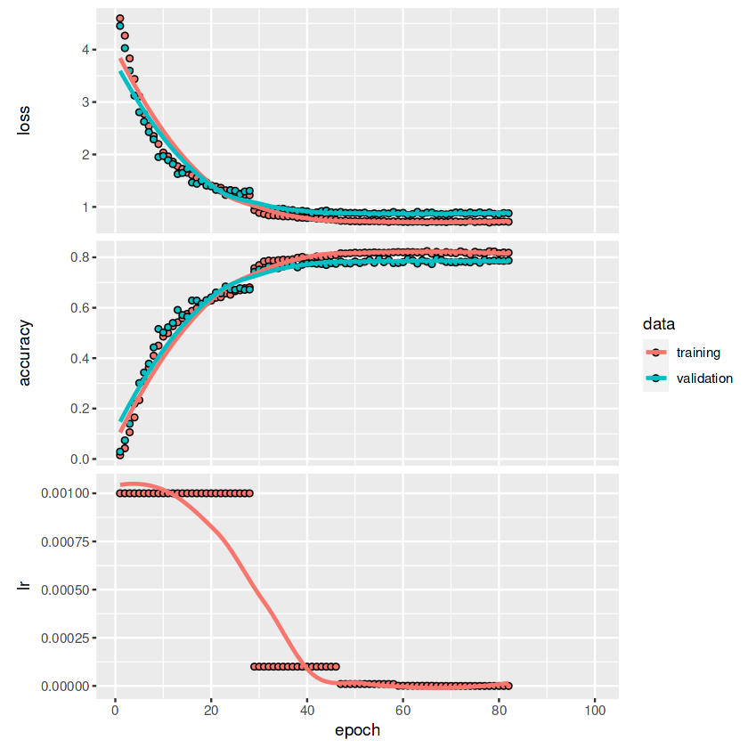

Wykresy accuracy i loss function na zbiorze uczącym

### Model 7

W następnym etapie postanowiliśmy zmienić “callback_reduce_lr_on_plateau(patience=3)” aby learning rate zmieniał się jeszcze szybciej.

```
## Model: "sequential_5"
## ________________________________________________________________________________
##  Layer (type)                       Output Shape                    Param #
## ================================================================================
##  conv2d_42 (Conv2D)                 (None, 150, 150, 16)            448
##  leaky_re_lu_38 (LeakyReLU)         (None, 150, 150, 16)            0
##  conv2d_41 (Conv2D)                 (None, 150, 150, 32)            4640
##  leaky_re_lu_37 (LeakyReLU)         (None, 150, 150, 32)            0
##  conv2d_40 (Conv2D)                 (None, 148, 148, 64)            18496
##  leaky_re_lu_36 (LeakyReLU)         (None, 148, 148, 64)            0
##  max_pooling2d_18 (MaxPooling2D)    (None, 74, 74, 64)              0
##  conv2d_39 (Conv2D)                 (None, 74, 74, 16)              9232
##  leaky_re_lu_35 (LeakyReLU)         (None, 74, 74, 16)              0
##  conv2d_38 (Conv2D)                 (None, 72, 72, 32)              4640
##  leaky_re_lu_34 (LeakyReLU)         (None, 72, 72, 32)              0
##  max_pooling2d_17 (MaxPooling2D)    (None, 36, 36, 32)              0
##  conv2d_37 (Conv2D)                 (None, 34, 34, 64)              18496
##  leaky_re_lu_33 (LeakyReLU)         (None, 34, 34, 64)              0
##  conv2d_36 (Conv2D)                 (None, 32, 32, 32)              18464
##  leaky_re_lu_32 (LeakyReLU)         (None, 32, 32, 32)              0
##  max_pooling2d_16 (MaxPooling2D)    (None, 16, 16, 32)              0
##  conv2d_35 (Conv2D)                 (None, 14, 14, 16)              4624
##  leaky_re_lu_31 (LeakyReLU)         (None, 14, 14, 16)              0
##  flatten_5 (Flatten)                (None, 3136)                    0
##  dense_17 (Dense)                   (None, 256)                     803072
##  leaky_re_lu_30 (LeakyReLU)         (None, 256)                     0
##  activity_regularization_7 (Activit  (None, 256)                    0
##  yRegularization)
##  dense_16 (Dense)                   (None, 64)                      16448
##  leaky_re_lu_29 (LeakyReLU)         (None, 64)                      0
##  activity_regularization_6 (Activit  (None, 64)                     0
##  yRegularization)
##  dense_15 (Dense)                   (None, 100)                     6500
## ================================================================================
## Total params: 905,060
## Trainable params: 905,060
## Non-trainable params: 0
## ________________________________________________________________________________
```

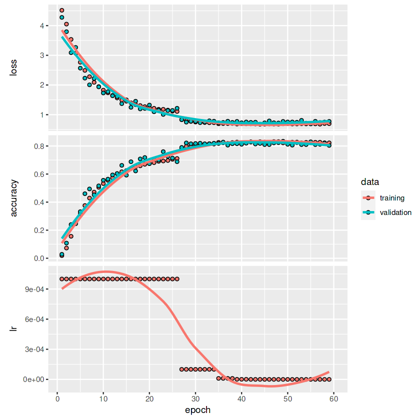

Wykresy accuracy i loss function na zbiorze uczącym

Zmniejszenie szybkości uczenia poprawiło działanie modelu.

### Model 8

W kolejnym kroku spróbowaliśmy dodać dodatkową warstwę konwolucyjną z filtrem=8.

```
## Model: "sequential_6"
## ________________________________________________________________________________
##  Layer (type)                       Output Shape                    Param #
## ================================================================================
##  conv2d_51 (Conv2D)                 (None, 150, 150, 16)            448
##  leaky_re_lu_49 (LeakyReLU)         (None, 150, 150, 16)            0
##  conv2d_50 (Conv2D)                 (None, 150, 150, 32)            4640
##  leaky_re_lu_48 (LeakyReLU)         (None, 150, 150, 32)            0
##  conv2d_49 (Conv2D)                 (None, 148, 148, 64)            18496
##  leaky_re_lu_47 (LeakyReLU)         (None, 148, 148, 64)            0
##  max_pooling2d_21 (MaxPooling2D)    (None, 74, 74, 64)              0
##  conv2d_48 (Conv2D)                 (None, 74, 74, 16)              9232
##  leaky_re_lu_46 (LeakyReLU)         (None, 74, 74, 16)              0
##  conv2d_47 (Conv2D)                 (None, 72, 72, 32)              4640
##  leaky_re_lu_45 (LeakyReLU)         (None, 72, 72, 32)              0
##  max_pooling2d_20 (MaxPooling2D)    (None, 36, 36, 32)              0
##  conv2d_46 (Conv2D)                 (None, 34, 34, 64)              18496
##  leaky_re_lu_44 (LeakyReLU)         (None, 34, 34, 64)              0
##  conv2d_45 (Conv2D)                 (None, 32, 32, 32)              18464
##  leaky_re_lu_43 (LeakyReLU)         (None, 32, 32, 32)              0
##  max_pooling2d_19 (MaxPooling2D)    (None, 16, 16, 32)              0
##  conv2d_44 (Conv2D)                 (None, 14, 14, 16)              4624
##  leaky_re_lu_42 (LeakyReLU)         (None, 14, 14, 16)              0
##  conv2d_43 (Conv2D)                 (None, 12, 12, 8)               1160
##  leaky_re_lu_41 (LeakyReLU)         (None, 12, 12, 8)               0
##  flatten_6 (Flatten)                (None, 1152)                    0
##  dense_20 (Dense)                   (None, 256)                     295168
##  leaky_re_lu_40 (LeakyReLU)         (None, 256)                     0
##  activity_regularization_9 (Activit  (None, 256)                    0
##  yRegularization)
##  dense_19 (Dense)                   (None, 64)                      16448
##  leaky_re_lu_39 (LeakyReLU)         (None, 64)                      0
##  activity_regularization_8 (Activit  (None, 64)                     0
##  yRegularization)
##  dense_18 (Dense)                   (None, 100)                     6500
## ================================================================================
## Total params: 398,316
## Trainable params: 398,316
## Non-trainable params: 0
## ________________________________________________________________________________
```

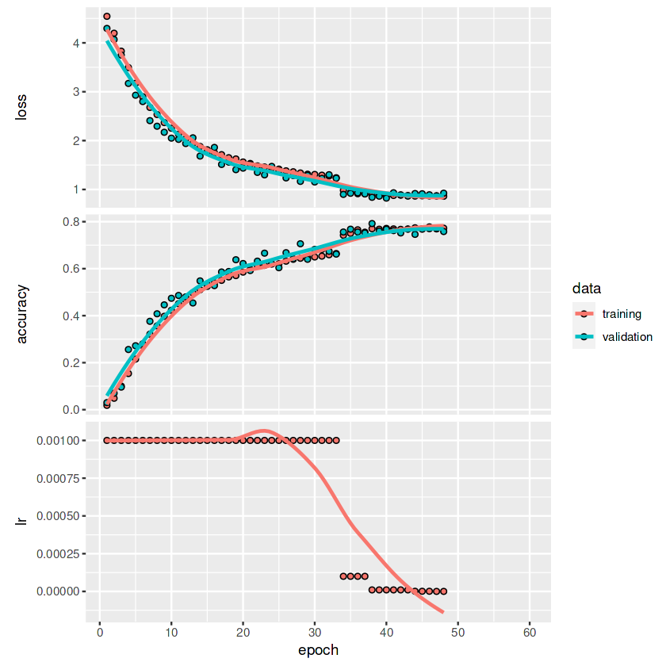

Wykresy accuracy i loss function na zbiorze uczącym

### Model 9

Dodanie warstwy nie poprawiło dopasowania modelu, ale w ramach testu dodaliśmy jeszcze jedną warstwę z maxpoolingiem.

```
## Model: "sequential_7"
## ________________________________________________________________________________
##  Layer (type)                       Output Shape                    Param #
## ================================================================================
##  conv2d_60 (Conv2D)                 (None, 150, 150, 16)            448
##  leaky_re_lu_60 (LeakyReLU)         (None, 150, 150, 16)            0
##  conv2d_59 (Conv2D)                 (None, 150, 150, 32)            4640
##  leaky_re_lu_59 (LeakyReLU)         (None, 150, 150, 32)            0
##  conv2d_58 (Conv2D)                 (None, 148, 148, 64)            18496
##  leaky_re_lu_58 (LeakyReLU)         (None, 148, 148, 64)            0
##  max_pooling2d_25 (MaxPooling2D)    (None, 74, 74, 64)              0
##  conv2d_57 (Conv2D)                 (None, 74, 74, 16)              9232
##  leaky_re_lu_57 (LeakyReLU)         (None, 74, 74, 16)              0
##  conv2d_56 (Conv2D)                 (None, 72, 72, 32)              4640
##  leaky_re_lu_56 (LeakyReLU)         (None, 72, 72, 32)              0
##  max_pooling2d_24 (MaxPooling2D)    (None, 36, 36, 32)              0
##  conv2d_55 (Conv2D)                 (None, 34, 34, 64)              18496
##  leaky_re_lu_55 (LeakyReLU)         (None, 34, 34, 64)              0
##  conv2d_54 (Conv2D)                 (None, 32, 32, 32)              18464
##  leaky_re_lu_54 (LeakyReLU)         (None, 32, 32, 32)              0
##  max_pooling2d_23 (MaxPooling2D)    (None, 16, 16, 32)              0
##  conv2d_53 (Conv2D)                 (None, 14, 14, 16)              4624
##  leaky_re_lu_53 (LeakyReLU)         (None, 14, 14, 16)              0
##  conv2d_52 (Conv2D)                 (None, 12, 12, 8)               1160
##  leaky_re_lu_52 (LeakyReLU)         (None, 12, 12, 8)               0
##  max_pooling2d_22 (MaxPooling2D)    (None, 6, 6, 8)                 0
##  flatten_7 (Flatten)                (None, 288)                     0
##  dense_23 (Dense)                   (None, 256)                     73984
##  leaky_re_lu_51 (LeakyReLU)         (None, 256)                     0
##  activity_regularization_11 (Activi  (None, 256)                    0
##  tyRegularization)
##  dense_22 (Dense)                   (None, 64)                      16448
##  leaky_re_lu_50 (LeakyReLU)         (None, 64)                      0
##  activity_regularization_10 (Activi  (None, 64)                     0
##  tyRegularization)
##  dense_21 (Dense)                   (None, 100)                     6500
## ================================================================================
## Total params: 177,132
## Trainable params: 177,132
## Non-trainable params: 0
## ________________________________________________________________________________
```

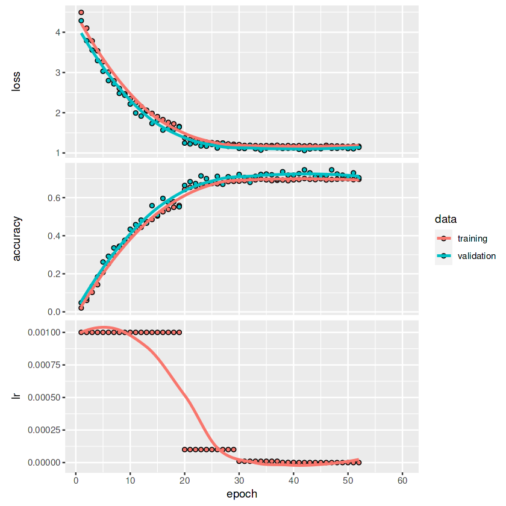

Wykresy accuracy i loss function na zbiorze uczącym

Jak widać obie te warstwy okazały się być zbędne i obniżały wartości metryki accuracy, więc wróciliśmy do poprzedniej wersji sieci.

### Model 10

Następnie przeprowadziliśmy normalizacje batch’a.

```
## Model: "sequential_8"
## ________________________________________________________________________________
##  Layer (type)                  Output Shape               Param #    Trainable
## ================================================================================
##  conv2d_68 (Conv2D)            (None, 150, 150, 16)       448        Y
##  batch_normalization_2 (BatchN  (None, 150, 150, 16)      64         Y
##  ormalization)
##  leaky_re_lu_70 (LeakyReLU)    (None, 150, 150, 16)       0          Y
##  conv2d_67 (Conv2D)            (None, 150, 150, 32)       4640       Y
##  leaky_re_lu_69 (LeakyReLU)    (None, 150, 150, 32)       0          Y
##  conv2d_66 (Conv2D)            (None, 148, 148, 64)       18496      Y
##  leaky_re_lu_68 (LeakyReLU)    (None, 148, 148, 64)       0          Y
##  max_pooling2d_28 (MaxPooling2  (None, 74, 74, 64)        0          Y
##  D)
##  conv2d_65 (Conv2D)            (None, 74, 74, 16)         9232       Y
##  batch_normalization_1 (BatchN  (None, 74, 74, 16)        64         Y
##  ormalization)
##  leaky_re_lu_67 (LeakyReLU)    (None, 74, 74, 16)         0          Y
##  conv2d_64 (Conv2D)            (None, 72, 72, 32)         4640       Y
##  leaky_re_lu_66 (LeakyReLU)    (None, 72, 72, 32)         0          Y
##  max_pooling2d_27 (MaxPooling2  (None, 36, 36, 32)        0          Y
##  D)
##  conv2d_63 (Conv2D)            (None, 34, 34, 64)         18496      Y
##  leaky_re_lu_65 (LeakyReLU)    (None, 34, 34, 64)         0          Y
##  conv2d_62 (Conv2D)            (None, 32, 32, 32)         18464      Y
##  leaky_re_lu_64 (LeakyReLU)    (None, 32, 32, 32)         0          Y
##  max_pooling2d_26 (MaxPooling2  (None, 16, 16, 32)        0          Y
##  D)
##  conv2d_61 (Conv2D)            (None, 14, 14, 16)         4624       Y
##  batch_normalization (BatchNor  (None, 14, 14, 16)        64         Y
##  malization)
##  leaky_re_lu_63 (LeakyReLU)    (None, 14, 14, 16)         0          Y
##  flatten_8 (Flatten)           (None, 3136)               0          Y
##  dense_26 (Dense)              (None, 256)                803072     Y
##  leaky_re_lu_62 (LeakyReLU)    (None, 256)                0          Y
##  activity_regularization_13 (A  (None, 256)               0          Y
##  ctivityRegularization)
##  dense_25 (Dense)              (None, 64)                 16448      Y
##  leaky_re_lu_61 (LeakyReLU)    (None, 64)                 0          Y
##  activity_regularization_12 (A  (None, 64)                0          Y
##  ctivityRegularization)
##  dense_24 (Dense)              (None, 100)                6500       Y
## ================================================================================
## Total params: 905,252
## Trainable params: 905,156
## Non-trainable params: 96
## ________________________________________________________________________________
```

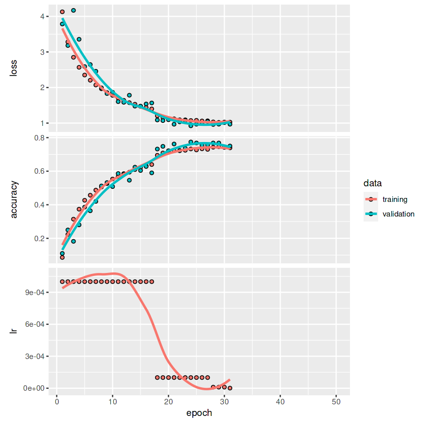

Wykresy accuracy i loss function na zbiorze uczącym

W tym przypadku róznież nie poprawiło się dopasowanie modelu.

### Model 11

Następnie spróbowaliśmy zredukować model po przez usunięcie ostatniej warstwy konwolucyjnej.

```
## Model: "sequential_9"
## ________________________________________________________________________________
##  Layer (type)                       Output Shape                    Param #
## ================================================================================
##  conv2d_75 (Conv2D)                 (None, 150, 150, 16)            448
##  leaky_re_lu_79 (LeakyReLU)         (None, 150, 150, 16)            0
##  conv2d_74 (Conv2D)                 (None, 150, 150, 32)            4640
##  leaky_re_lu_78 (LeakyReLU)         (None, 150, 150, 32)            0
##  conv2d_73 (Conv2D)                 (None, 148, 148, 64)            18496
##  leaky_re_lu_77 (LeakyReLU)         (None, 148, 148, 64)            0
##  max_pooling2d_31 (MaxPooling2D)    (None, 74, 74, 64)              0
##  conv2d_72 (Conv2D)                 (None, 74, 74, 16)              9232
##  leaky_re_lu_76 (LeakyReLU)         (None, 74, 74, 16)              0
##  conv2d_71 (Conv2D)                 (None, 72, 72, 32)              4640
##  leaky_re_lu_75 (LeakyReLU)         (None, 72, 72, 32)              0
##  max_pooling2d_30 (MaxPooling2D)    (None, 36, 36, 32)              0
##  conv2d_70 (Conv2D)                 (None, 34, 34, 64)              18496
##  leaky_re_lu_74 (LeakyReLU)         (None, 34, 34, 64)              0
##  conv2d_69 (Conv2D)                 (None, 32, 32, 32)              18464
##  leaky_re_lu_73 (LeakyReLU)         (None, 32, 32, 32)              0
##  max_pooling2d_29 (MaxPooling2D)    (None, 16, 16, 32)              0
##  flatten_9 (Flatten)                (None, 8192)                    0
##  dense_29 (Dense)                   (None, 256)                     2097408
##  leaky_re_lu_72 (LeakyReLU)         (None, 256)                     0
##  activity_regularization_15 (Activi  (None, 256)                    0
##  tyRegularization)
##  dense_28 (Dense)                   (None, 64)                      16448
##  leaky_re_lu_71 (LeakyReLU)         (None, 64)                      0
##  activity_regularization_14 (Activi  (None, 64)                     0
##  tyRegularization)
##  dense_27 (Dense)                   (None, 100)                     6500
## ================================================================================
## Total params: 2,194,772
## Trainable params: 2,194,772
## Non-trainable params: 0
## ________________________________________________________________________________
```

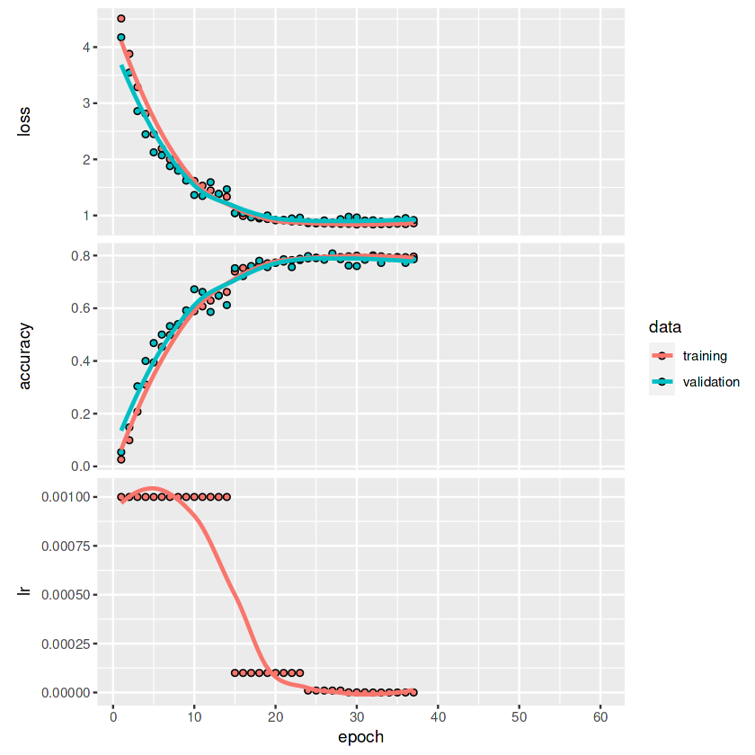

Wykresy accuracy i loss function na zbiorze uczącym

Widać niewielką poprawe jeżeli chodzi o accuracy modelu.

### Model 12

Na koniec postanowiliśmy dodać jeszcze jedną warstwę z maxpoolingiem .

```
## Model: "sequential_10"
## ________________________________________________________________________________
##  Layer (type)                       Output Shape                    Param #
## ================================================================================
##  conv2d_82 (Conv2D)                 (None, 150, 150, 16)            448
##  leaky_re_lu_88 (LeakyReLU)         (None, 150, 150, 16)            0
##  conv2d_81 (Conv2D)                 (None, 150, 150, 32)            4640
##  leaky_re_lu_87 (LeakyReLU)         (None, 150, 150, 32)            0
##  conv2d_80 (Conv2D)                 (None, 148, 148, 64)            18496
##  leaky_re_lu_86 (LeakyReLU)         (None, 148, 148, 64)            0
##  max_pooling2d_35 (MaxPooling2D)    (None, 74, 74, 64)              0
##  conv2d_79 (Conv2D)                 (None, 74, 74, 16)              9232
##  leaky_re_lu_85 (LeakyReLU)         (None, 74, 74, 16)              0
##  conv2d_78 (Conv2D)                 (None, 72, 72, 32)              4640
##  leaky_re_lu_84 (LeakyReLU)         (None, 72, 72, 32)              0
##  max_pooling2d_34 (MaxPooling2D)    (None, 36, 36, 32)              0
##  conv2d_77 (Conv2D)                 (None, 34, 34, 64)              18496
##  leaky_re_lu_83 (LeakyReLU)         (None, 34, 34, 64)              0
##  conv2d_76 (Conv2D)                 (None, 32, 32, 32)              18464
##  leaky_re_lu_82 (LeakyReLU)         (None, 32, 32, 32)              0
##  max_pooling2d_33 (MaxPooling2D)    (None, 16, 16, 32)              0
##  max_pooling2d_32 (MaxPooling2D)    (None, 8, 8, 32)                0
##  flatten_10 (Flatten)               (None, 2048)                    0
##  dense_32 (Dense)                   (None, 256)                     524544
##  leaky_re_lu_81 (LeakyReLU)         (None, 256)                     0
##  activity_regularization_17 (Activi  (None, 256)                    0
##  tyRegularization)
##  dense_31 (Dense)                   (None, 64)                      16448
##  leaky_re_lu_80 (LeakyReLU)         (None, 64)                      0
##  activity_regularization_16 (Activi  (None, 64)                     0
##  tyRegularization)
##  dense_30 (Dense)                   (None, 100)                     6500
## ================================================================================
## Total params: 621,908
## Trainable params: 621,908
## Non-trainable params: 0
## ________________________________________________________________________________
```

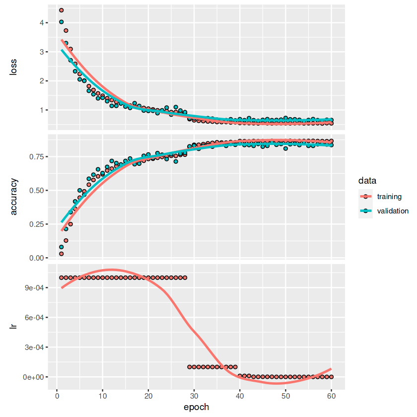

Wykresy accuracy i loss function na zbiorze uczącym

## Podsumowanie

Na podstawie wykresów ciężko powiedzieć który model był najlepszy na zbiorze uczącym i walidacyjnym, dlatego przygotowaliśmy tabele przedstawiącą wyniki 3 najlepszych modeli na zbiorze testowym.

| Model | accuracy | loss |
| --- | --- | --- |
| Model 12 | 0.898 | 0.413 |
| Model 11 | 0.862 | 0.657 |
| Model 9 | 0.824 | 0.670 |

### Model 12

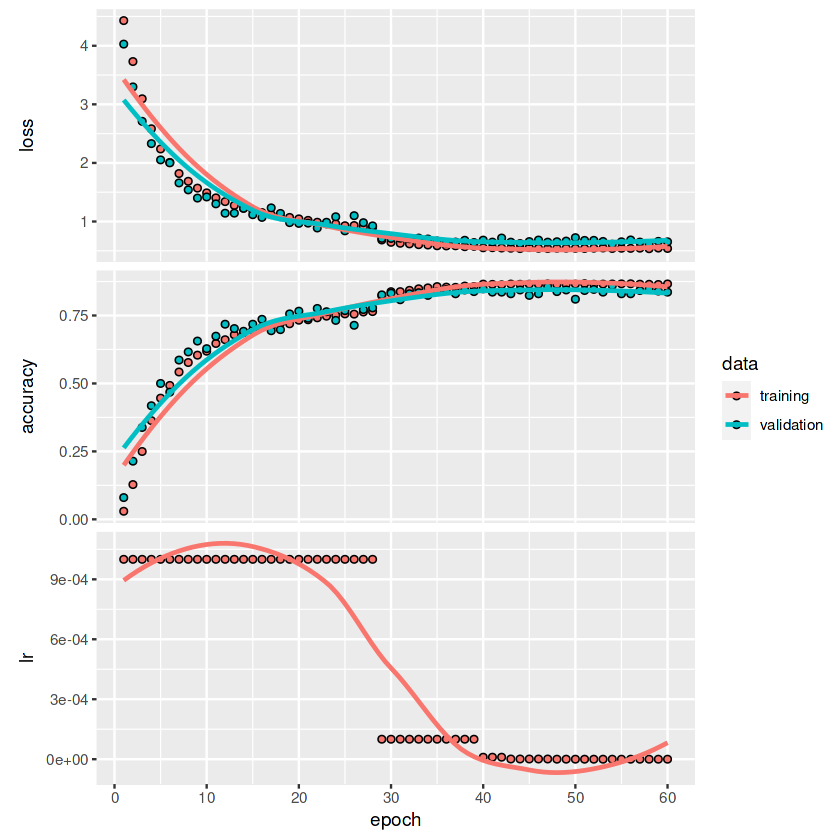

### Model 11

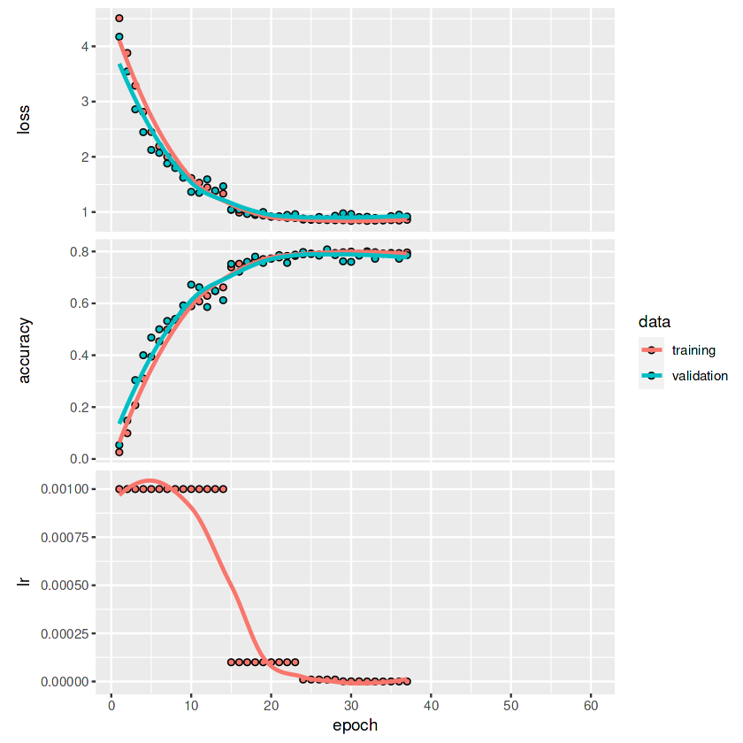

### Model 9

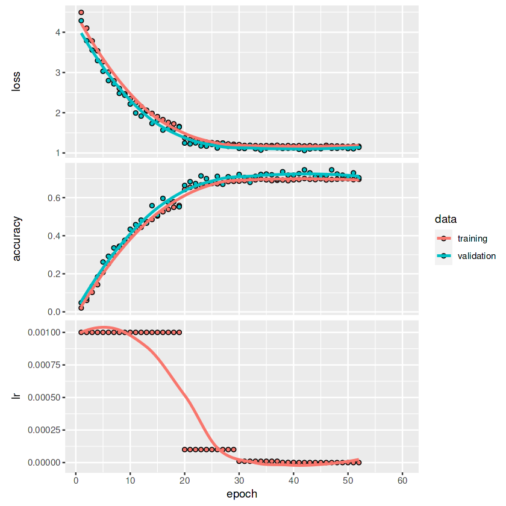

Na podstawie tabeli i na podstawie wykresów histori uczenia możemy powiedzieć że ostatni model jest najlepszy. Proces uczenia nie wskazuje przeuczenia, a wynik 90% accuracy na zbiorze testowym jest zadowalającym wynikiem.

[Całość procesu uczenia można znaleźć tutaj](https://www.kaggle.com/code/lajcior/projet?scriptVersionId=135442018)

## ad

Celem naszego projektu na wstępie była próba utworzenia sieci klasyfikującej wykresy kwantylowe w zależności od tego czy pochodziły z rozkładu normalnego czy też nie. Niestety po 40+ godzinach zużycia GPU i 50+ wersjach projektu na platformie kaggle musieliśmy zrezygnować z projektu. Nieważne co robiliśmy nie udało nam sie zniwelować przeuczenia modelu (prawdopodobnie popełniliśmy błąd w przygotowaniu plotów). Większą cześć prac można znaleźć tutaj [(link)](https://www.kaggle.com/code/mioszalfler/cvproj)